# Task 1.2 Apply Quantum Operations

## Objective 2 : Quantum Circuit

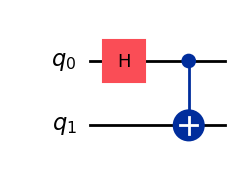

```python
from qiskit import QuantumCircuit

# Create a new circuit with two qubits
qc = QuantumCircuit(2)

# Add a Hadamard gate to qubit 0
qc.h(0)

# Perform a controlled-X gate on qubit 1, controlled by qubit 0
qc.cx(0, 1)

# Return a text drawing of the circuit.
qc.draw('mpl')
```

Core attribute is Data

```python
print(qc.data)
```

[output not shown]

global phase

```python
print(qc.global_phase)
```

```
0.0
```

Quantum and Classical Registers

```python
print(qc.qregs)
print(qc.cregs)
```

```
[QuantumRegister(2, 'q')]
[]
```

Layout

```python
from qiskit import QuantumCircuit
from qiskit.providers.fake_provider import GenericBackendV2
from qiskit.transpiler import generate_preset_pass_manager

# Create circuit to test transpiler on
qc = QuantumCircuit(3, 3)
qc.h(0)
qc.cx(0, 1)
qc.swap(1, 2)
qc.cx(0, 1)

# Add measurements to the circuit
qc.measure([0, 1, 2], [0, 1, 2])

# Specify the QPU to target
backend = GenericBackendV2(3)

# Transpile the circuit
pass_manager = generate_preset_pass_manager(
optimization_level=1, backend=backend
)
transpiled = pass_manager.run(qc)

# Print the layout after transpilation
print(transpiled.layout.routing_permutation())
```

```
[0, 1, 2]
```

Create Circuits

- Init
- Copy
- Copy Empty Like
- from Instruction
- from qasm file
- from qasm string

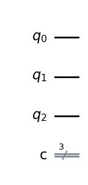

```python
qc2 = qc.copy_empty_like()
qc2.draw('mpl')
```

Data Objects

- add_bits
- add_register
- add_var
- add_stretch
- add_input
- add_capture
- add_uninitialized_var

```python
from qiskit.circuit import QuantumCircuit

qc = QuantumCircuit(2)
my_var = qc.add_var("my_var", False)
```

Working with bits

```python
from qiskit.circuit import QuantumCircuit, Qubit

qc = QuantumCircuit(3, 3)
qc.h(0)
qc.cx(0, 1)
qc.cx(1, 2)
qc.measure([0, 1, 2], [0, 1, 2])

# The `.qubits` and `.clbits` fields are not integers.
assert isinstance(qc.data[0].qubits[0], Qubit)
# ... but we can use `find_bit` to retrieve them.
assert qc.find_bit(qc.data[0].qubits[0]).index == 0

simple = [
    (
        instruction.operation.name,
        [qc.find_bit(bit).index for bit in instruction.qubits],
        [qc.find_bit(bit).index for bit in instruction.clbits],
    )
    for instruction in qc.data
]
```

Adding Operations

- append
- _append
- compose
- tensor

```python
qc2.x(0)
qc.tensor(qc2).draw()
```

```
     ┌───┐
q_0: ┤ X ├───────────────────
     └───┘
q_1: ────────────────────────

q_2: ────────────────────────
     ┌───┐          ┌─┐
q_3: ┤ H ├──■───────┤M├──────
     └───┘┌─┴─┐     └╥┘┌─┐
q_4: ─────┤ X ├──■───╫─┤M├───
          └───┘┌─┴─┐ ║ └╥┘┌─┐
q_5: ──────────┤ X ├─╫──╫─┤M├
               └───┘ ║  ║ └╥┘
c: 6/════════════════╩══╩══╩═
                     3  4  5
```

Methods to add standard instructions

special non-unitary

- barrier
- delay
- initialize
- measure
- reset
- store

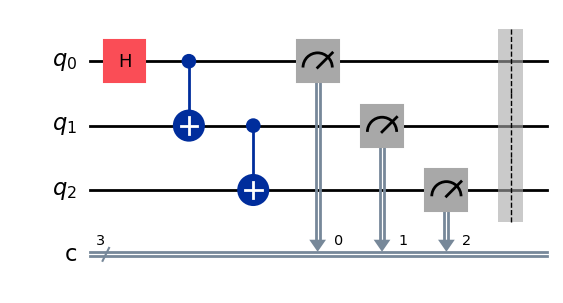

```python
qc.barrier()

qc.draw('mpl')
```

Uncontrolled unitary Gate

- dcx
- ecr
- h
- id
- iswap
- ms
- p
- pauli
- prepare_state
- r
- rcccx
- rccx
- rv
- rx
- rxx
- ry
- ryy
- rz
- rzx
- rzz
- s
- sdg
- swap
- sx
- sxdg
- t
- tdg
- u
- unitary
- x
- y
- z

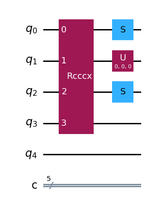

```python
qc = QuantumCircuit(5,5)

qc.rcccx(0,1,2,3)
qc.s([0,2])
qc.u(0,0,0,1)

qc.draw('mpl')
```

Controlled Unitary Gates

- ccx
- ccz
- ch
- cp
- crx
- cry
- crz
- cs
- csdg
- cswap
- csx
- cu
- cx
- cy
- cz

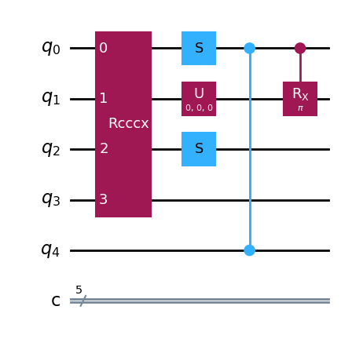

```python
qc.cz(0,4)
qc.crx(np.pi,0,1)


qc.draw('mpl')
```

Multiply Controlled Gates

- mcp
- mcrx
- mcry
- mcrz
- mcx

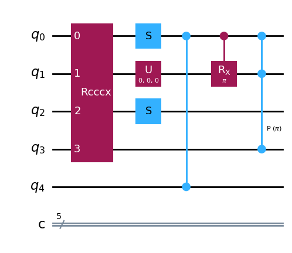

```python
qc.mcp(np.pi,[0,1],3)

qc.draw('mpl')
```

Adding Control Flow to circuits

- if_test
- if_else
- while_loop
- switch
- for_loop
- box
- break_loop
- continue_loop

```python
from qiskit.circuit import QuantumCircuit, BoxOp

body_0 = QuantumCircuit(4)
body_0.cz(0, 1)
body_0.cz(2, 3)

# Note that the qubit indices inside a body related only to the body.  The
# association with qubits in the containing circuit is made by the ``qubits``
# argument to `QuantumCircuit.box`.
body_1 = QuantumCircuit(5)
body_1.cz(0, 1)
body_1.cz(2, 3)

qc = QuantumCircuit(9)
qc.box(body_0, [0, 1, 2, 3], [])
qc.box(body_1, [4, 5, 6, 7, 8], [])

qc.draw()
```

```
     ┌───────     ───────┐
q_0: ┤        ─■─        ├───────────────────────
     │         │         │
q_1: ┤        ─■─        ├───────────────────────
     │ Box-0       End-0 │
q_2: ┤        ─■─        ├───────────────────────
     │         │         │
q_3: ┤        ─■─        ├───────────────────────
     └───────     ───────┘ ┌───────     ───────┐
q_4: ──────────────────────┤        ─■─        ├─
                           │         │         │
q_5: ──────────────────────┤        ─■─        ├─
                           │                   │
q_6: ──────────────────────┤ Box-0  ─■─  End-0 ├─
                           │         │         │
q_7: ──────────────────────┤        ─■─        ├─
                           │                   │
q_8: ──────────────────────┤        ───        ├─
                           └───────     ───────┘
```

```python
from qiskit.circuit import QuantumCircuit


qc = QuantumCircuit(9)
with qc.box():
    qc.cz(0, 1)
    qc.cz(2, 3)
with qc.box():
    qc.cz(4, 5)
    qc.cz(6, 7)
    qc.noop(8)

qc.draw()
```

```
     ┌───────     ───────┐
q_0: ┤        ─■─        ├───────────────────────
     │         │         │
q_1: ┤        ─■─        ├───────────────────────
     │ Box-0       End-0 │
q_2: ┤        ─■─        ├───────────────────────
     │         │         │
q_3: ┤        ─■─        ├───────────────────────
     └───────     ───────┘ ┌───────     ───────┐
q_4: ──────────────────────┤        ─■─        ├─
                           │         │         │
q_5: ──────────────────────┤        ─■─        ├─
                           │                   │
q_6: ──────────────────────┤ Box-0  ─■─  End-0 ├─
                           │         │         │
q_7: ──────────────────────┤        ─■─        ├─
                           │                   │
q_8: ──────────────────────┤        ───        ├─
                           └───────     ───────┘
```

```python
from qiskit import QuantumCircuit
qc = QuantumCircuit(2, 1)

with qc.for_loop(range(5)) as i:
    qc.x(0)
    qc.cx(0, 1)
    qc.measure(0, 0)
    with qc.if_test((0, True)):
        qc.break_loop()

qc.draw()
```

```
     ┌─────────────────── ┌───┐     ┌─┐┌────── ┌─────────────┐ ───────┐ »
q_0: ┤                    ┤ X ├──■──┤M├┤       ┤1            ├        ├─»
     │ For-0 range(0, 5)  └───┘┌─┴─┐└╥┘│ If-1  │             │  End-1 │ »
q_1: ┤                    ─────┤ X ├─╫─┤       ┤0 Break_loop ├        ├─»
     └───────────────────      └───┘ ║ └──╥─── │             │ ───────┘ »
  c: ════════════════════════════════╩════■════╡0            ╞══════════»
                                               └─────────────┘          »
«      ───────┐
«q_0:         ├─
«       End-0 │
«q_1:         ├─
«      ───────┘
«  c: ══════════
«
```

```python
from qiskit.circuit import QuantumCircuit

qc = QuantumCircuit(3)
with qc.box():
    # This control-flow block will only use qubits 0 and 1.
    qc.cx(0, 1)
with qc.box():
    # This control-flow block will contain only the same operation as the previous
    # block, but it will also mark qubit 2 as "used" by the box.
    qc.cx(0, 1)
    qc.noop(2)
```

Converting circuits to single objects

- to_instruction
- to_gate

```python
instructions_list = qc2.to_instruction()
print(instructions_list)

qc3= QuantumCircuit(3)

qc3.x(0)
qc3.measure_active()
qc3.draw()

gates=qc3.to_gate()
print(gates)
```

```
Instruction(name='circuit-165', num_qubits=3, num_clbits=3, params=[])
```

[output not shown]

Helper mutation Methods

- measure_active
- measure_all
- clear
- remove_final_measurments

```python
qc3= QuantumCircuit(3)

qc3.h(0)
qc3.cx(0,2)
qc3.measure_active()
qc3.draw()
```

```
        ┌───┐      ░ ┌─┐
   q_0: ┤ H ├──■───░─┤M├───
        └───┘  │   ░ └╥┘
   q_1: ───────┼───░──╫────
             ┌─┴─┐ ░  ║ ┌─┐
   q_2: ─────┤ X ├─░──╫─┤M├
             └───┘ ░  ║ └╥┘
meas: 2/══════════════╩══╩═
                      0  1
```

```python
qc3.remove_final_measurements()
qc3.draw()
```

```
     ┌───┐
q_0: ┤ H ├──■──
     └───┘  │
q_1: ───────┼──
          ┌─┴─┐
q_2: ─────┤ X ├
          └───┘
```

Simple Circuit Metrics

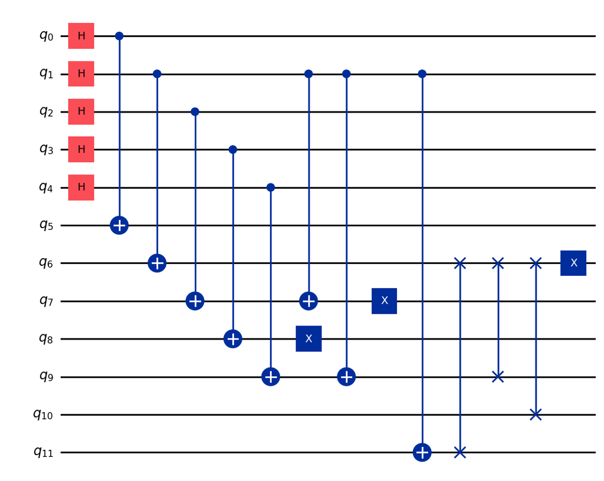

```python
from qiskit import QuantumCircuit
qc = QuantumCircuit(12)
for idx in range(5):
   qc.h(idx)
   qc.cx(idx, idx+5)

qc.cx(1, 7)
qc.x(8)
qc.cx(1, 9)
qc.x(7)
qc.cx(1, 11)
qc.swap(6, 11)
qc.swap(6, 9)
qc.swap(6, 10)
qc.x(6)
qc.draw('mpl')
```

```python
assert qc.width() == 12
```

```python
assert qc.num_qubits == 12
```

```python
qc.count_ops()
```

```
OrderedDict([('cx', 8), ('h', 5), ('x', 3), ('swap', 3)])
```

Accessing Scheduling Information

- estimate_duration
- qubit_duration
- qubit_start_time
- qubit_stop_time

Instruction-like methods

- control
- inverse

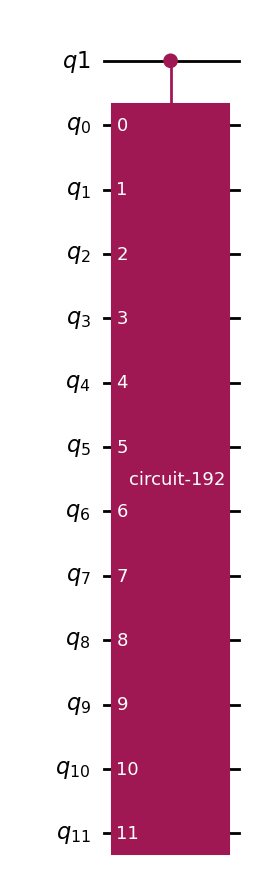

```python
qc.control(1).draw('mpl')
```

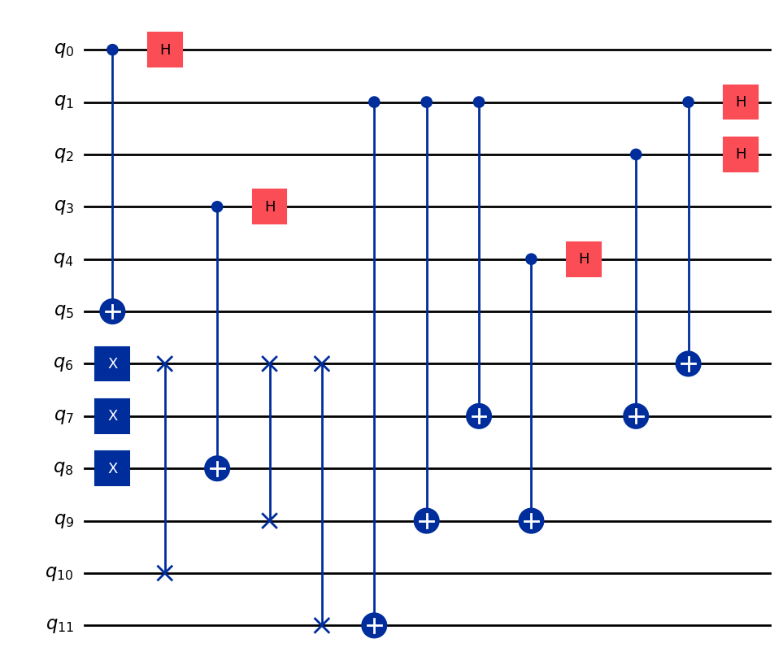

```python
qc.inverse().draw('mpl')
```

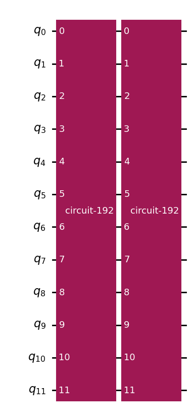

```python
qc.power(2).draw('mpl')
```

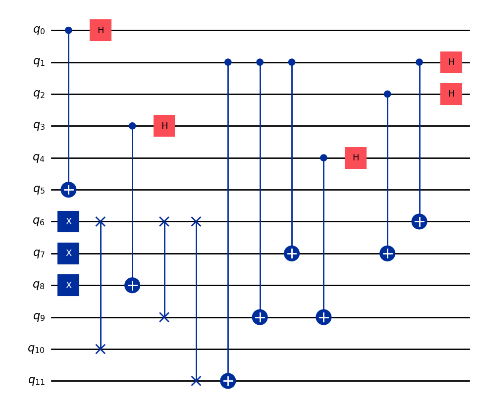

```python
qc.reverse_ops().draw('mpl')
```

Visualization

- draw
- decompose
- reverse_bits

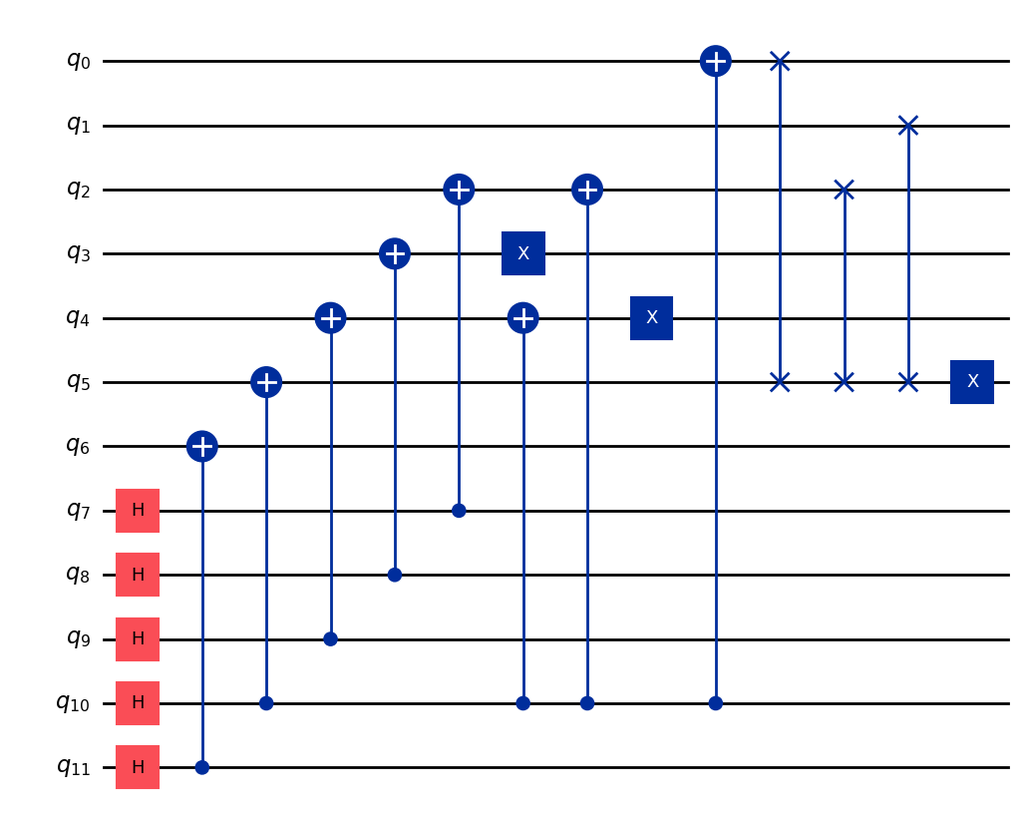

```python
qc.reverse_bits().draw('mpl')
```